# Grushin_K_Bayes

### Иерархическая модель для Регби

#### Грушин Константин - АБД19-1м

```python
# Импортируем необходимые библиотеки

%matplotlib inline
import numpy as np
import pandas as pd
from matplotlib import pyplot as plt
import pymc3 as pm
import theano.tensor as tt
# try:
#     from StringIO import StringIO
# except ImportError:
#     from io import StringIO
from matplotlib.ticker import StrMethodFormatter
import seaborn as sns
```

**Данные о Лиге шести наций.**  
Соревнования по Регби между Италией, Ирландией, Шотландией, Англией, Францией и Уэльсом.

Первоисточником данных является Википедия.  
Данные доступны по ссылке - https://github.com/kgrushin/master_finance_public/blob/main/rugby.csv  
Работа подготовлена на основе:  
материалов и гайдов библиотеки PYMC3 - https://docs.pymc.io/  
поста Daniel Weitzenfeld’s - http://danielweitzenfeld.github.io/passtheroc/blog/2014/10/28/bayes-premier-league/  
книги Вероятностное программирование на Python: байесовский вывод и алгоритмы [2019] Дэвидсон-Пайлон К.

```python
# Загружаем данные
df_all = pd.read_csv('data/rugby.csv', index_col=0)
```

```python
print(df_all.shape)
df_all.head()
```

```
(60, 5)
```

|  | home_team | away_team | home_score | away_score | year |
| --- | --- | --- | --- | --- | --- |
| 0 | Wales | Italy | 23 | 15 | 2014 |
| 1 | France | England | 26 | 24 | 2014 |
| 2 | Ireland | Scotland | 28 | 6 | 2014 |
| 3 | Ireland | Wales | 26 | 3 | 2014 |
| 4 | Scotland | England | 0 | 20 | 2014 |

Описание полей

- home_team - команда, которая играет "дома"
- away_team - команда, которая играет "в гостях"
- home_score - очки команды, которая играет "дома"
- away_score - очки команды, которая играет "в гостях"
- year - год, в который играли команды

```python
df_all['year'].value_counts()
```

```
2017    15
2016    15
2015    15
2014    15
Name: year, dtype: int64
```

Как определить насколько одна команда сильнее другой?  
Мы попробуем вывести скрытый параметр "сила команды" основываясь только на полученных очках за игры в течение 4 лет и построить модель Чемпионата шести наций в 2018 году.

### EDA

```python
df_all.describe()
```

|  | home_score | away_score | year |
| --- | --- | --- | --- |
| count | 60.000000 | 60.000000 | 60.000000 |
| mean | 23.500000 | 19.983333 | 2015.500000 |
| std | 14.019962 | 12.911028 | 1.127469 |
| min | 0.000000 | 0.000000 | 2014.000000 |
| 25% | 16.000000 | 10.000000 | 2014.750000 |
| 50% | 20.500000 | 18.000000 | 2015.500000 |
| 75% | 27.250000 | 23.250000 | 2016.250000 |
| max | 67.000000 | 63.000000 | 2017.000000 |

```python
df_all['diff'] = abs(df_all['home_score'] - df_all['away_score'])
```

```python
pd.concat([df_all[['year','diff']].groupby('year').min(),
           df_all[['year','diff']].groupby('year').mean(),
           df_all[['year','diff']].groupby('year').max(),
           df_all[['year','diff']].groupby('year').std()], axis=1)
```

| year | diff | diff | diff | diff |
| --- | --- | --- | --- | --- |
| 2014 | 1 | 17.533333 | 48 | 15.482094 |
| 2015 | 3 | 15.600000 | 41 | 12.199532 |
| 2016 | 0 | 14.066667 | 53 | 15.818013 |
| 2017 | 2 | 17.000000 | 53 | 15.014279 |

По абсолютной разнице в очках нельзя оценить насколько одна команда сильнее другой, но видно, что стандартное отклонение по годам достаточно велико

```python
df_all['diff_non_abs']= df_all['home_score']- df_all['away_score']
```

```python
df_all.pivot_table('diff_non_abs', 'home_team', 'year')
```

| year home_team | 2014 | 2015 | 2016 | 2017 |
| --- | --- | --- | --- | --- |
| England | 7.000000 | 20.666667 | 7.500000 | 21.333333 |
| France | 6.666667 | 0.000000 | -2.333333 | 4.000000 |
| Ireland | 28.000000 | 8.500000 | 17.666667 | 7.000000 |
| Italy | -21.000000 | -31.000000 | -23.500000 | -33.666667 |
| Scotland | -11.000000 | -12.000000 | 2.500000 | 16.666667 |
| Wales | 25.666667 | 1.000000 | 22.000000 | 4.000000 |

```python
# Чем больше, тем больше домашних игр выиграно
```

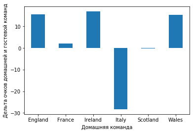

```python
(df_all.pivot_table('diff_non_abs', 'home_team')
      .rename_axis("Домашняя команда")
      .plot(kind='bar', rot=0, legend=False)
      .set_ylabel('Дельта очков домашней и гостевой команд')
);
```

```python
# Чем больше, тем больше гостевых игр проиграно
```

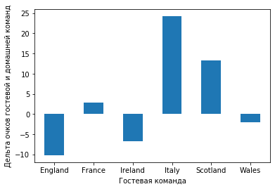

```python
(df_all.pivot_table('diff_non_abs', 'away_team')
      .rename_axis("Гостевая команда")
      .plot(kind='bar', rot=0, legend=False)
      .set_ylabel('Дельта очков гостевой и домашней команд')
);
```

### Что нам по итогу EDA известно?

- Италия, Шотландия и Франция достаточно плохо играют вне дома.
- Англия же играет вне дома хорошо
- Италия вцелом играет плохо
- Представлены 6 команд, играющих единожды друг с другом раз в году
- Данные даны за 4 года подряд
- Игра дома - преимущество
- **Кол-во очков имеет распределение Пуассона**

### Моделирование

В сезоне 15 игр.  
$y_{g1} - $ Кол-во очков, набранных хозяевами $g$-м матче сезона  
$y_{g2} - $ Кол-во очков, набранных гостями $g$-м матче сезона  
$y = (y_{g1}, y_{g2}) - $ вектор наблюдаемых результатов игры, моделируемый с помощью распределения Пуассона

$ y_{gi}|𝜃_{gi} \sim Poisson(𝜃_{gi}) $

где тета - интенсивность набора очков командой, играющий дома при j=1 и на выезде j=2, в g-й игре

Моделируем эти параметры, исходя из лог-линейной модели случайных эффектов:  
$ 𝑙𝑜𝑔𝜃_{𝑔1} = ℎ𝑜𝑚𝑒 + 𝑎𝑡𝑡_ℎ(𝑔) + 𝑑𝑒𝑓_𝑎(𝑔) $  
$ 𝑙𝑜𝑔𝜃_{𝑔2} = 𝑎𝑡𝑡_𝑎(𝑔) + 𝑑𝑒𝑓_ℎ(𝑔) $  
, где $home$ - преимущество для команды, играющей дома (предполагаем, что $Const.$)  
Интенсивность набора очков командой определяется вместе с атакующими ($att$) и защитными ($def$) способностями каждой из команд.

И для каждого $t = 1,…, T$ специфические для команды эффекты моделируются как заменяемые из общего распределения:  
$ 𝑎𝑡𝑡_𝑡 \sim 𝑁𝑜𝑟𝑚𝑎𝑙(𝜇_{𝑎𝑡𝑡}, 𝜏_{𝑎𝑡𝑡}) $  
$ 𝑑𝑒𝑓_𝑡 \sim 𝑁𝑜𝑟𝑚𝑎𝑙(𝜇_{𝑑𝑒𝑓}, 𝜏_{𝑑𝑒𝑓}) $

```python
df = df_all[['home_team', 'away_team', 'home_score', 'away_score']].copy()
```

```python
# Для удобства пронумеруем команды в датасете
```

```python
teams = df['home_team'].unique()
teams = pd.DataFrame(teams, columns=['team'])
teams['i'] = teams.index

df = pd.merge(df, teams, left_on='home_team', right_on='team', how='left')
df = df.rename(columns = {'i': 'i_home'}).drop('team', 1)
df = pd.merge(df, teams, left_on='away_team', right_on='team', how='left')
df = df.rename(columns = {'i': 'i_away'}).drop('team', 1)

observed_home_goals = df['home_score'].values
observed_away_goals = df['away_score'].values

home_team = df['i_home'].values
away_team = df['i_away'].values

num_teams = len(df['i_home'].drop_duplicates())
num_games = len(home_team)
```

```python
num_teams
```

```
6
```

```python
num_games
```

```
60
```

```python
df.head()
```

|  | home_team | away_team | home_score | away_score | i_home | i_away |
| --- | --- | --- | --- | --- | --- | --- |
| 0 | Wales | Italy | 23 | 15 | 0 | 4 |
| 1 | France | England | 26 | 24 | 1 | 5 |
| 2 | Ireland | Scotland | 28 | 6 | 2 | 3 |
| 3 | Ireland | Wales | 26 | 3 | 2 | 0 |
| 4 | Scotland | England | 0 | 20 | 3 | 5 |

#### Используемые распределения

1. **HalfStundetT** - sd_att, sd_att

[figure not shown]

2. **Flat** - Intercept, home - плоское априорное распределение, равномерно для всего интервала величины
3. **Normal** - defs_star, atts_star

[figure not shown]

```python
with pm.Model() as model:

    # Глобальные параметры модели
    home = pm.Flat('home') # плоское априорное распределение, равномерно для всего интервала величины
    sd_att = pm.HalfStudentT('sd_att', nu=3, sigma=2.5) #
    sd_def = pm.HalfStudentT('sd_def', nu=3, sigma=2.5)
    intercept = pm.Flat('intercept')

    # Специфичные параметры для команды
    atts_star = pm.Normal("atts_star", mu=0, sigma=sd_att, shape=num_teams)
    defs_star = pm.Normal("defs_star", mu=0, sigma=sd_def, shape=num_teams)
    atts = pm.Deterministic('atts', atts_star - tt.mean(atts_star))
    defs = pm.Deterministic('defs', defs_star - tt.mean(defs_star))
    home_theta = tt.exp(intercept + home + atts[home_team] + defs[away_team])
    away_theta = tt.exp(intercept + atts[away_team] + defs[home_team])

    # Функция правдоподобия
    home_points = pm.Poisson('home_points', mu=home_theta, observed=observed_home_goals)
    away_points = pm.Poisson('away_points', mu=away_theta, observed=observed_away_goals)
```

В сезоне 15 игр.  
$y_{g1} - $ Кол-во очков, набранных хозяевами $g$-м матче сезона  
$y_{g2} - $ Кол-во очков, набранных гостями $g$-м матче сезона  
$y = (y_{g1}, y_{g2}) - $ вектор наблюдаемых результатов игры, моделируемый с помощью распределения Пуассона

$ y_{gi}|𝜃_{gi} \sim Poisson(𝜃_{gi}) $

где тета - интенсивность набора очков командой, играющий дома при j=1 и на выезде j=2, в g-й игре

Моделируем эти параметры, исходя из лог-линейной модели случайных эффектов:  
$ 𝑙𝑜𝑔𝜃_{𝑔1} = ℎ𝑜𝑚𝑒 + 𝑎𝑡𝑡_ℎ(𝑔) + 𝑑𝑒𝑓_𝑎(𝑔) $  
$ 𝑙𝑜𝑔𝜃_{𝑔2} = 𝑎𝑡𝑡_𝑎(𝑔) + 𝑑𝑒𝑓_ℎ(𝑔) $  
, где $home$ - преимущество для команды, играющей дома (предполагаем, что $Const.$)  
Интенсивность набора очков командой определяется вместе с атакующими ($att$) и защитными ($def$) способностями каждой из команд.

И для каждого $t = 1,…, T$ специфические для команды эффекты моделируются как заменяемые из общего распределения:  
$ 𝑎𝑡𝑡_𝑡 \sim 𝑁𝑜𝑟𝑚𝑎𝑙(𝜇_{𝑎𝑡𝑡}, 𝜏_{𝑎𝑡𝑡}) $  
$ 𝑑𝑒𝑓_𝑡 \sim 𝑁𝑜𝑟𝑚𝑎𝑙(𝜇_{𝑑𝑒𝑓}, 𝜏_{𝑑𝑒𝑓}) $

#### Сэмплируем наши параметры с помощью MCMC и получаем апостериорные вероятности параметров нашей модели

```
Auto-assigning NUTS sampler...
Initializing NUTS using jitter+adapt_diag...
Multiprocess sampling (2 chains in 2 jobs)
NUTS: [defs_star, atts_star, intercept, sd_def, sd_att, home]
```

100.00% [4000/4000 00:10<00:00 Sampling 2 chains, 0 divergences]

```
Sampling 2 chains for 1_000 tune and 1_000 draw iterations (2_000 + 2_000 draws total) took 20 seconds.
```

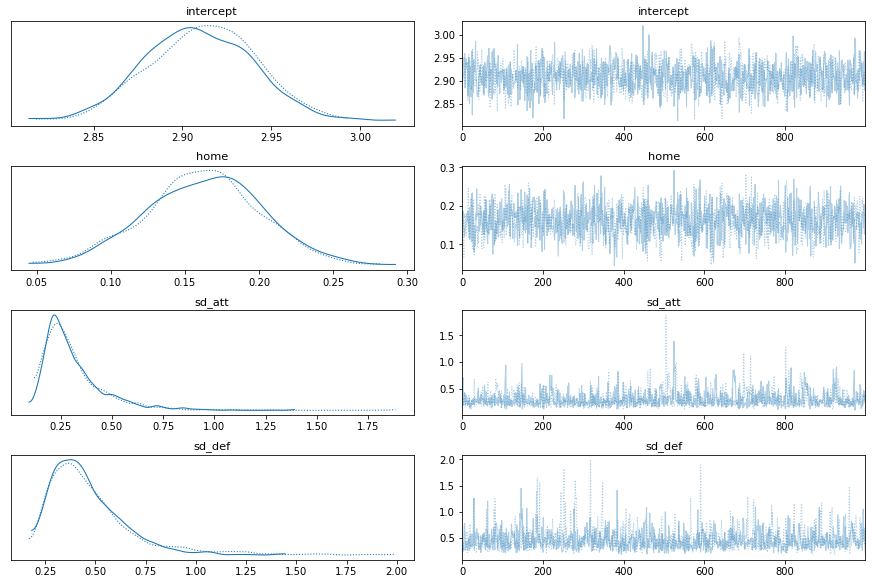

```python
with model:
    trace = pm.sample(1000)

pm.traceplot(trace, var_names=['intercept', 'home', 'sd_att', 'sd_def']);
```

Вычисляем highest posterior density - наилучшую апостериорную плотность, т.е. вычисляем байесовский надежный интервал минимальной ширины

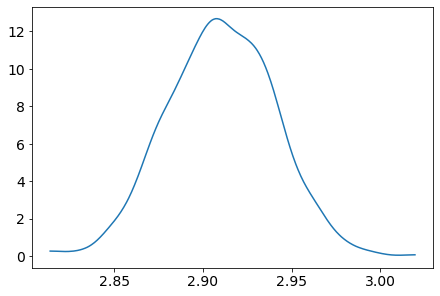

```python
pm.plot_dist(trace['intercept'])
```

```python
df_hpd = pd.DataFrame(pm.stats.hpd(trace['atts']),
                      columns=['hpd_low', 'hpd_high'],
                      index=teams.team.values)
```

```python
df_hpd
```

|  | hpd_low | hpd_high |
| --- | --- | --- |
| Wales | 0.092652 | 0.246690 |
| France | -0.161720 | 0.008585 |
| Ireland | 0.025866 | 0.191546 |
| Scotland | -0.216120 | -0.029137 |
| Italy | -0.443856 | -0.235105 |
| England | 0.176580 | 0.326551 |

```python
df_median = pd.DataFrame(np.quantile(trace['atts'], 0.5, axis=0),
                         columns=['hpd_median'],
                         index=teams.team.values)
```

```python
df_median
```

|  | hpd_median |
| --- | --- |
| Wales | 0.171802 |
| France | -0.082488 |
| Ireland | 0.108229 |
| Scotland | -0.115762 |
| Italy | -0.334902 |
| England | 0.252525 |

```python
df_hpd = df_hpd.join(df_median)
df_hpd['relative_lower'] = df_hpd.hpd_median - df_hpd.hpd_low
df_hpd['relative_upper'] = df_hpd.hpd_high - df_hpd.hpd_median
df_hpd = df_hpd.sort_values(by='hpd_median')
df_hpd = df_hpd.reset_index()
df_hpd['x'] = df_hpd.index + .5
```

```python
df_hpd
```

|  | index | hpd_low | hpd_high | hpd_median | relative_lower | relative_upper | x |
| --- | --- | --- | --- | --- | --- | --- | --- |
| 0 | Italy | -0.443856 | -0.235105 | -0.334902 | 0.108955 | 0.099797 | 0.5 |
| 1 | Scotland | -0.216120 | -0.029137 | -0.115762 | 0.100358 | 0.086625 | 1.5 |
| 2 | France | -0.161720 | 0.008585 | -0.082488 | 0.079233 | 0.091072 | 2.5 |
| 3 | Ireland | 0.025866 | 0.191546 | 0.108229 | 0.082363 | 0.083316 | 3.5 |
| 4 | Wales | 0.092652 | 0.246690 | 0.171802 | 0.079150 | 0.074888 | 4.5 |
| 5 | England | 0.176580 | 0.326551 | 0.252525 | 0.075946 | 0.074026 | 5.5 |

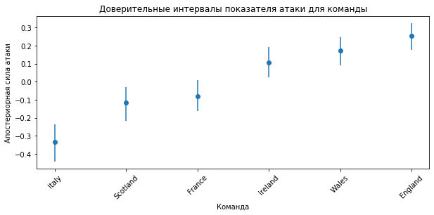

```python
fig, axs = plt.subplots(figsize=(10,4))
axs.errorbar(df_hpd.x, df_hpd.hpd_median,
             yerr=(df_hpd[['relative_lower', 'relative_upper']].values).T,
             fmt='o')
axs.set_title('Доверительные интервалы показателя атаки для команды')
axs.set_xlabel('Команда')
axs.set_ylabel('Апостериорная сила атаки')
_= axs.set_xticks(df_hpd.index + .5)
_= axs.set_xticklabels(df_hpd['index'].values, rotation=45)
```

Заметно, что некоторые доверительные интервалы по показателю атаки пересекаются. А также подтверждается гипотеза о том, что Италия является слабой командой в атаке.

#### Смоделируем, кто выиграет в 2018 году на основе сэмплирования

```python
with model:
    pp_trace = pm.sample_posterior_predictive(trace)
```

100.00% [2000/2000 00:03<00:00]

```python
home_sim_df = pd.DataFrame({
    'sim_points_{}'.format(i): 3 * home_won
    for i, home_won in enumerate(pp_trace['home_points'] > pp_trace['away_points'])
})
home_sim_df.insert(0, 'team', df['home_team'])

away_sim_df = pd.DataFrame({
    'sim_points_{}'.format(i): 3 * away_won
    for i, away_won in enumerate(pp_trace['home_points'] < pp_trace['away_points'])
})
away_sim_df.insert(0, 'team', df['away_team'])
```

```python
sim_table = (home_sim_df.groupby('team')
                        .sum()
                        .add(away_sim_df.groupby('team')
                                        .sum())
                        .rank(ascending=False, method='min', axis=0)
                        .reset_index()
                        .melt(id_vars='team', value_name='rank')
                        .groupby('team')
             ['rank']
             .value_counts()
             .unstack(level='rank')
             .fillna(0))
n_samples = sim_table.sum(axis=1).values[0]
sim_table = sim_table.div(n_samples)
```

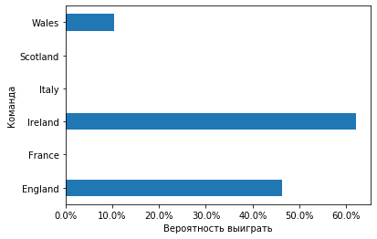

```python
ax = sim_table.loc[:, 1.0].plot(kind='barh')

ax.xaxis.set_major_formatter(StrMethodFormatter('{x:.1%}'));
ax.set_xlabel("Вероятность выиграть");

ax.set_ylabel("Команда");
```

В соответствие с нашей моделью видим, что Ирландия победит с наибольшим количеством очков примерно в 60% случаев, Англия в 45% случаев, а Уэльс примерно в 10% случаев.

**По данным википедии, победителем в 2018 году является Ирландия.**